# Probability Theory

X610 · Session 1 · *FoAS* Chapter 1

## Course texts

[figure not shown]

Aronow & Miller — *FoAS*

[figure not shown]

Clayton — *BF*

# Today

- Probability spaces, events, and the axioms of probability
- Joint and conditional probability, independence, and Bayes’ rule
- Random variables, support, and distribution functions
- Joint, marginal, and conditional distributions of multiple random variables

Reading: *FoAS* Ch. 1; *Bernoulli’s Fallacy* Intro + Ch. 1

# Probability foundations

## Notation (1)

| Notation | Definition and usage |
| --- | --- |
| $\mathbb{R}$ | The set of all real numbers — all the points on a continuous number line. |
| $\in$ | Set membership. $s \in A$ (read “$s$ is an element of $A$”) denotes that the object $s$ is an element of the set $A$. |
| $\subseteq$ | Subset. $A \subseteq B$ means $B$ contains every element of $A$: $A \subseteq B \Longleftrightarrow \forall s \in A, s \in B$. For example, $\{2,3,5\} \subseteq \{1,2,3,4,5\}$. |
| $\forall$ | For all. States that all elements of a particular set satisfy a given expression. For example, $\forall x \in \{1,2,3,4,5\}, 2x \leq 10$. |
| $A^C$ | The complement of a set: all elements of the universal set $U$ that are not in $A$. Formally, $A^C = \{s \in U : s \notin A\}$. |
| $A \setminus B$ | Set subtraction: all elements in $A$ except any also in $B$. Formally, $A \setminus B = \{s \in A : s \notin B\}$. |
| $\emptyset$ | The empty set — the set containing no elements. |

## Notation (2)

| Notation | Definition and usage |
| --- | --- |
| $\cup$ | Union. $A \cup B$ contains all elements in either $A$ or $B$ (or both). For example, $\{1,2,5\} \cup \{2,3\} = \{1,2,3,5\}$. |
| $\cap$ | Intersection. $A \cap B$ contains all elements in both $A$ and $B$. For example, $\{1,2,5,6\} \cap \{2,3,6\} = \{2,6\}$. |
| $\lvert A \rvert$ | The cardinality (size) of a set. For finite sets, the number of elements: $\lvert\{1,2,3,5,6,8\}\rvert = 6$. |
| $\mathcal{P}(A)$ | The power set of $A$: the set of all subsets of $A$. |

## Notation (3)

| Notation | Definition and usage |
| --- | --- |
| $\sum$ | Summation of a sequence. For example, $\sum_{j=1}^{4} j^2 = 1 + 4 + 9 + 16 = 30$. |
| $f: S \rightarrow T$ | A function $f$ from $S$ to $T$. $S$ is the domain; $T$ is the codomain, containing all possible values of $f(s)$. |
| $\Longleftrightarrow$ | If and only if. Two statements are logically equivalent; each implies the other. For example, $2x = 10 \Longleftrightarrow x = 5$. |
| $\square$ | Quod erat demonstrandum (QED). Denotes that a proof is complete. |
| $\triangle$ | End of example (*FoAS*’s nonstandard delimiter). |

## Random generative processes

- A **random generative process** is a mechanism that selects an outcome from among multiple possible outcomes
- A single instance of selecting an outcome is a **draw** or **realization**
- Examples: flipping a coin, rolling a die, drawing a ball from an urn, selecting a person at random from a group

## Probability is a *model*

> Probability theory is a model, which is an approximation of reality. Everyday macrophysical processes are not actually characterized by fundamental randomness. … The mathematical construct of randomness is, therefore, a modeling assumption, not necessarily a fundamental feature of reality. —*FoAS*, pp. 4–5

> All models are wrong, but some are useful. —George Box

> Truth is much too complicated to allow anything but approximations. —John von Neumann

## Weather forecasts

What do these probabilities mean?

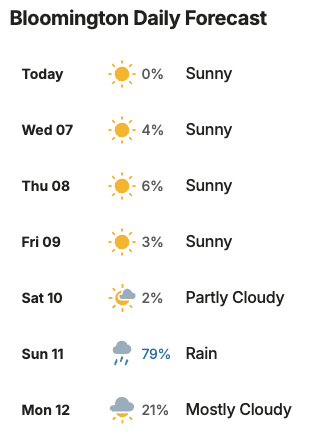

## Frequentist probability

- *FoAS* adopts the **frequentist** interpretation:

> “The probability of an event describes the proportion of times that event can be expected to occur among many realizations of a random generative process. … It is the long-run average or limiting value of the frequency of observing event $A$ among repeated realizations of the generative process.” (*FoAS*, p. 4)
- *Bernoulli’s Fallacy* challenges this interpretation

## Python setup

Every code example in this course assumes this preamble:

```python
import numpy as np
import matplotlib.pyplot as plt
from scipy import stats

rng = np.random.default_rng(610)
```

- `rng` is our *seeded* random number generator: everyone’s simulations give identical results

## Long-run frequency, simulated

```python
flips = rng.integers(0, 2, size=100_000)   # 1 = heads, 0 = tails
running_freq = np.cumsum(flips) / np.arange(1, flips.size + 1)

print(running_freq[[9, 99, 999, 9_999, 99_999]])
```

```
[0.4     0.38    0.48    0.4959  0.49908]
```

- The relative frequency of heads stabilizes near $\tfrac{1}{2}$ as draws accumulate
- This is the frequentist notion of probability

## Probability space

| Component | Symbol | What it is |
| --- | --- | --- |
| Sample space | $\Omega$ | Set of all possible outcomes $\omega$ |
| Event space | $S$ | Set of subsets of $\Omega$ (the events) |
| Probability measure | $P$ | Function assigning a probability to every event |

- Die roll: $\Omega = \{1,2,3,4,5,6\}$
  - “roll an even number” is the event $A = \{2,4,6\}$

## Event space

**Definition 1.1.1 — Event Space**

A set $S$ of subsets of $\Omega$ is an **event space** if it satisfies the following:

- Nonempty: $S \neq \emptyset$.
- Closed under complements: if $A \in S$, then $A^C \in S$.
- Closed under countable unions: if $A_1, A_2, A_3, \ldots \in S$, then $A_1 \cup A_2 \cup A_3 \cup \ldots \in S$.
- Why:
  - if $A$ has a probability, “not $A$” must also;
  - if “$A$ and $B$” has a probability, “$A$ or $B$” must also

## The Kolmogorov axioms

**Definition 1.1.2 — Kolmogorov Axioms**

$(\Omega, S, P)$ is a **probability space** if it satisfies the following:

- Non-negativity: $\forall A \in S$, $P(A) \geq 0$, where $P(A)$ is finite and real.
- Unitarity: $P(\Omega) = 1$.
- Countable additivity: if $A_1, A_2, A_3, \ldots \in S$ are pairwise disjoint, then
  $$P(A_1 \cup A_2 \cup A_3 \cup \ldots) = P(A_1) + P(A_2) + P(A_3) + \ldots = \sum_i P(A_i).$$

## The Kolmogorov axioms, in words

1. No event has negative probability
2. *Something* in $\Omega$ has to happen
3. For mutually exclusive events, probabilities add
- Everything else in probability theory is *derived* from these three axioms

## A fair coin flip

Let $H$ represent the outcome “heads” and $T$ represent the outcome “tails.” Let $\Omega=\{H, T\}$ and $S=\{\emptyset,\{H\},\{T\},\{H, T\}\}$. Define the probability measure as:

$$P(A)=\frac{1}{2}|A|, \quad \forall A \in S .$$

This means that:

- $P(\emptyset)=\frac{1}{2}|\emptyset|=\frac{1}{2} \cdot 0=0$. The probability of nothing happening is zero.
- $P(\{H\})=\frac{1}{2}|\{H\}|=\frac{1}{2} \cdot 1=\frac{1}{2}$. The probability of getting heads is $\frac{1}{2}$.
- $P(\{T\})=\frac{1}{2}|\{T\}|=\frac{1}{2} \cdot 1=\frac{1}{2}$. The probability of getting tails is $\frac{1}{2}$.
- $P(\{H, T\})=\frac{1}{2}|\{H, T\}|=\frac{1}{2} \cdot 2=1$. The probability of getting either heads or tails is one.

Since $S$ is a proper event space and that $P$ satisfies the Kolmogorov axioms, $(\Omega, S, P)$ is a probability space.

## Andrey Kolmogorov (1903–1987)

- Soviet mathematician, professor at Moscow State University, and one of the most influential mathematicians of the 20th century
- His 1933 monograph *Foundations of the Theory of Probability* put probability on a rigorous footing by grounding it in measure theory
- Before Kolmogorov, probability was a collection of useful techniques with disputed foundations; after him, it was a branch of mathematics
- He made fundamental contributions beyond probability: turbulence, dynamical systems, and algorithmic complexity
- Famously devoted to teaching, he also wrote school textbooks and mentored dozens of doctoral students

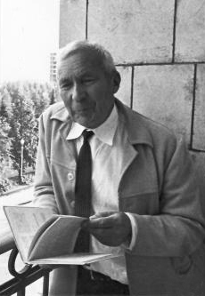

## Basic properties of probability

**Theorem 1.1.4 — Basic Properties of Probability**

Let $(\Omega, S, P)$ be a probability space. Then, $\forall A, B \in S$:

- Monotonicity: if $A \subseteq B$, then $P(A) \leq P(B)$.
- Subtraction rule: if $A \subseteq B$, then $P(B \setminus A) = P(B) - P(A)$.
- Zero probability of the empty set: $P(\emptyset) = 0$.
- Probability bounds: $0 \leq P(A) \leq 1$.
- Complement rule: $P(A^C) = 1 - P(A)$.

## Joint probability

**Definition 1.1.5 — Joint Probability**

For $A, B \in S$, the **joint probability** of $A$ and $B$ is $P(A \cap B)$.

**Example 1.1.6 — A Fair Die Roll**

$\Omega = \{1,\ldots,6\}$, $P(A) = \frac{1}{6}|A|$. Let $A = \{4,5,6\}$ (“at least 4”) and $B = \{2,4,6\}$ (“even”). Then
$$P(A \cap B) = P(\{4, 6\}) = \frac{2}{6} = \frac{1}{3}.$$

## Addition rule

**Theorem 1.1.7 — Addition Rule**

For $A, B \in S$,
$$P(A \cup B) = P(A) + P(B) - P(A \cap B).$$

- Adding $P(A)$ and $P(B)$ double-counts the overlap $A \cap B$
- Disjoint events: reduces to $P(A \cup B) = P(A) + P(B)$, a special case of countable additivity

## Joint probability, simulated

```python
rolls = rng.integers(1, 7, size=100_000)

A = rolls >= 4          # Boolean value that is True if roll>=4
B = rolls % 2 == 0      # Boolean value that is True if roll is even

print('P(A∩B) ≈', (A & B).mean())            # 1/3
print('P(A∪B) ≈', (A | B).mean())            # 1/2 + 1/2 - 1/3 = 2/3
print('check  :', A.mean() + B.mean() - (A & B).mean())
```

```
P(A∩B) ≈ 0.33009
P(A∪B) ≈ 0.66688
check  : 0.66688
```

- Boolean arrays make event logic transparent: `&` is intersection, `|` is union, `.mean()` is relative frequency

## Conditional probability

**Definition 1.1.8 — Conditional Probability**

For $A, B \in S$ with $P(B) > 0$, the **conditional probability** of $A$ given $B$ is
$$P(A \mid B) = \frac{P(A \cap B)}{P(B)}.$$

- Conditioning = restricting attention to the draws where $B$ occurred

## Multiplicative law

**Theorem 1.1.9 — Multiplicative Law of Probability**

For $A, B \in S$ with $P(B) > 0$,
$$P(A \mid B)\, P(B) = P(A \cap B).$$

- Just a rearrangement of Definition 1.1.8 — but the rearranged form is how joint probabilities are usually *computed*
- In a multi-stage process, the conditional probabilities are what we know directly: each stage’s probabilities given the earlier stages
- The multiplicative law chains them into the probability that the whole sequence occurs. Example: Flip a coin, then roll a die…
  $$P(\text{heads} \cap \text{roll 3})
  = P(\text{roll 3} \mid \text{heads})\,P(\text{heads})$$

## Conditioning, simulated

```python
print('P(A|B) ≈', A[B].mean())      # restrict to draws where B occurred
print('exact  :', (2/6) / (3/6))    # P(A∩B)/P(B) = 2/3
```

```
P(A|B) ≈ 0.6619805871971763
exact  : 0.6666666666666666
```

- `A[B]` keeps only the realizations in which $B$ occurred — the simulation analog of conditioning
  - This “Boolean masking” is a common idiom in both Python and R

## Bayes’ rule

**Theorem 1.1.10 — Bayes’ Rule**

For $A, B \in S$ with $P(A) > 0$ and $P(B) > 0$,
$$P(A \mid B) = \frac{P(B \mid A)\, P(A)}{P(B)}.$$

- Reverses the direction of conditioning: relates $P(A \mid B)$ to $P(B \mid A)$

## Where our books disagree

- *FoAS*: “Although we will not be making use of Bayes’ Rule in this book, we would be remiss to neglect it entirely.”
- *BF*: this reversal is kind of the *whole point* — inference means getting from $P(\text{data} \mid \text{hypothesis})$ to $P(\text{hypothesis} \mid \text{data})$

## A two-stage process

**Example 1.1.11 — Flipping a Coin and Rolling a Die**

Flip a fair coin. Heads → roll a fair **four**-sided die; tails → roll a fair **six**-sided die. Let $A$ = heads, $B$ = observing 3.

$$P(A \cap B) = P(B \mid A) P(A) = \tfrac{1}{4} \cdot \tfrac{1}{2} = \tfrac{1}{8},
\qquad
P(A^C \cap B) = \tfrac{1}{6} \cdot \tfrac{1}{2} = \tfrac{1}{12}.$$

$$P(B) = P(A \cap B) + P(A^C \cap B) = \tfrac{1}{8} + \tfrac{1}{12} = \tfrac{5}{24}.$$

By Bayes’ rule:
$$P(A \mid B) = \frac{P(B \mid A) P(A)}{P(B)}
= \frac{\tfrac{1}{4} \cdot \tfrac{1}{2}}{\tfrac{5}{24}}
= \frac{3}{5}.$$

- Seeing a 3 makes heads *more* likely than the unconditional $\tfrac{1}{2}$ — a 3 is easier to get on a four-sided die

## The same process, simulated

```python
n = 100_000
heads = rng.random(n) < 0.5
die = np.where(heads,
               rng.integers(1, 5, size=n),    # 4-sided if heads
               rng.integers(1, 7, size=n))    # 6-sided if tails

three = die == 3
print('P(heads | rolled 3) ≈', heads[three].mean())
```

```
P(heads | rolled 3) ≈ 0.5980794286541524
```

- The simulation models Bayes’ rule: among draws where $B$ occurred, count how often $A$ also did

## Partitions

**Definition 1.1.12 — Partition**

If $A_1, A_2, A_3, \ldots \in S$ are nonempty and pairwise disjoint, and $\Omega = A_1 \cup A_2 \cup A_3 \cup \ldots$, then $\{A_1, A_2, A_3, \ldots\}$ is a **partition** of $\Omega$.

- A partition divides $\Omega$ into mutually exclusive, exhaustive “bins”: exactly one $A_i$ occurs on any draw

## Law of Total Probability

**Theorem 1.1.13 — Law of Total Probability**

If $\{A_1, A_2, A_3, \ldots\}$ is a partition of $\Omega$ and $B \in S$, then
$$P(B) = \sum_i P(B \cap A_i).$$
If we also have $P(A_i) > 0$ for $i = 1, 2, 3, \ldots$, then this can also be stated as
$$P(B) = \sum_i P(B \mid A_i)\, P(A_i).$$

- $P(B)$ is a weighted average of conditional probabilities, weighted by the $P(A_i)$

## Bayes’ rule, again

**Theorem 1.1.14 — Alternative Forms of Bayes’ Rule**

If $\{A_1, A_2, A_3, \ldots\}$ is a partition of $\Omega$ with $P(A_i) > 0$ for $i = 1, 2, 3, \ldots$, and $B \in S$ with $P(B) > 0$, then
$$P(A_j \mid B) = \frac{P(B \mid A_j)\, P(A_j)}{\sum_i P(B \mid A_i)\, P(A_i)}.$$

## Base rates matter

A disease affects 1% of a population. A test has:

- $P(+ \mid \text{sick}) = 0.95$ (*sensitivity* is 95%)
- $P(- \mid \text{healthy}) = 0.95$ (*specificity* is 95%)

You test positive. 🤒

**What is the probability that you have the disease?**

- Write down your answer before we simulate it

## Base rates matter: the answer

```python
n = 1_000_000
sick = rng.random(n) < 0.01
positive = np.where(sick, rng.random(n) < 0.95, rng.random(n) < 0.05)

print('P(sick | +) ≈', sick[positive].mean())
```

```
P(sick | +) ≈ 0.16084212669222678
```

- Roughly **16%**, not 95% — the prior $P(\text{sick}) = 0.01$ dominates
- This is Clayton’s *base rate neglect*: $P(+ \mid \text{sick})$ is not $P(\text{sick} \mid +)$

## Independence of events

**Definition 1.1.15 — Independence of Events**

Events $A, B \in S$ are **independent** if $P(A \cap B) = P(A)\,P(B)$.

**Theorem 1.1.16 — Conditional Probability and Independence**

For $A, B \in S$ with $P(B) > 0$, $A$ and $B$ are independent if and only if
$$P(A \mid B) = P(A).$$

- Independence: knowing whether $B$ occurred tells you *nothing* about $A$
- Coin-and-die example: $P(A \mid B) = \frac{3}{5} \neq \frac{1}{2} = P(A)$

# Random variables and probability distributions

## Notation (4)

| Notation | Definition and usage |
| --- | --- |
| $\exists$ | There exists. States that at least one element of a set satisfies an expression. For example, $\exists x \in \{1,2,3,4,5\}$ such that $x^2 = 16$. |
| $\mathbb{N}$ | The set of all natural numbers (positive integers): $\mathbb{N} = \{1, 2, 3, \ldots\}$. |
| $\mathbb{Z}$ | The set of all integers: $\mathbb{Z} = \{\ldots, -2, -1, 0, 1, 2, \ldots\}$. |
| $\mathbb{R}^n$ | The real coordinate space of dimension $n$: all vectors of length $n$ with real entries. |
| $f(A)$ | The image of the set $A$ under $f$: all values $f$ can take on when applied to an element of $A$. Note that $f(S)$ is the range of $f$ — e.g., $X(\Omega)$, the range of a random variable. |
| $g \circ f$ | Composition of two functions: first apply $f$, then $g$: $(g \circ f)(s) = g(f(s))$. |

## Random variables

**Definition 1.2.1 — Random Variable**

A random variable is a function $X: \Omega \rightarrow \mathbb{R}$ such that, $\forall r \in \mathbb{R}$,
$$\{\omega \in \Omega: X(\omega) \leq r\} \in S.$$

- Maps each state of the world to a real number
- “Neither random nor a variable” — it’s a function
  - The randomness comes from the underlying generative process, and the variable is the output of the function

## Random variables

- Some notation:
  - $X$ is the random variable and $x$ is a particular draw
  - $\{X = 1\}$, $\{X \geq 0\}$ are events in terms of the r.v.
  - $\Pr[X = 1]$ is the probability that a draw from the r.v. is 1
- So we can say things like $\Pr[X \leq x]$

## Discrete random variables

**Definition 1.2.4 — Discrete Random Variable**

A random variable $X$ is discrete if its range, $X(\Omega)$, is a countable set.

- Can be finite or countably infinite

**Definition 1.2.5 — Probability Mass Function (PMF)**

For a discrete random variable $X$, the probability mass function of $X$ is
$$f(x) = \Pr[X = x], \; \forall x \in \mathbb{R}.$$

## The Bernoulli random variable

**Example 1.2.7 — A Biased Coin Flip (Bernoulli Distribution)**

Let $X = 0$ if the coin comes up heads and $X = 1$ if tails, with $\Pr[X = 1] = p$. Then
$$f(x) = \begin{cases} 1 - p & : \; x = 0 \\ p & : \; x = 1 \end{cases}$$

$f(x) = 0$ for all other $x \in \mathbb{R}$.

- The simplest nontrivial random variable
- A whole family tree of related distributions grows out of this example

## Properties of PMFs

**Theorem 1.2.9 — Properties of PMFs**

For a discrete random variable $X$ with PMF $f$,

- $\forall x \in \mathbb{R},\; f(x) \geq 0$,
- $\sum_{x \in X(\Omega)} f(x) = 1$.
- Probabilities of events: sum the PMF over relevant values
- Die roll example:
  $$\Pr[X \geq 3] = \sum_{x=3}^{6} f(x) = \frac{2}{3}$$

## A PMF in code

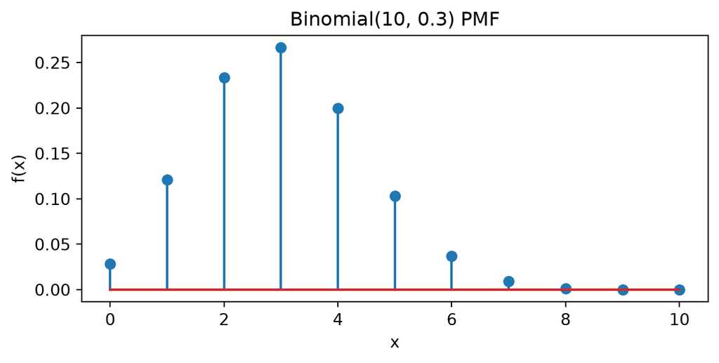

```python
X = stats.binom(n=10, p=0.3)    # the r.v.
x = np.arange(11)               # x = [0, 1, 2, ..., 10]

fig, ax = plt.subplots(figsize=(7, 3))
ax.stem(x, X.pmf(x))            # plot (x,y)
ax.set(xlabel='x', ylabel='f(x)', title='Binomial(10, 0.3) PMF')
plt.show()
```

## Cumulative distribution functions

**Definition 1.2.11 — Cumulative Distribution Function (CDF)**

For a random variable $X$, the cumulative distribution function of $X$ is
$$F(x) = \Pr[X \leq x], \; \forall x \in \mathbb{R}.$$

- *Every* random variable has a CDF — discrete, continuous, or otherwise
- The CDF tells us everything about the distribution of $X$

## Properties of CDFs

**Theorem 1.2.12 — Properties of CDFs**

For a random variable $X$ with CDF $F$,

- $F$ is nondecreasing: $\forall x_1, x_2 \in \mathbb{R}$, if $x_1 < x_2$, then $F(x_1) \leq F(x_2)$.
- $\lim_{x \rightarrow -\infty} F(x) = 0$.
- $\lim_{x \rightarrow \infty} F(x) = 1$.
- $\forall x \in \mathbb{R},\; 1 - F(x) = \Pr[X > x]$.
- For a discrete RV, the CDF is a *step function*:
  - flat, then jumps by $f(x)$

## The die-roll CDF

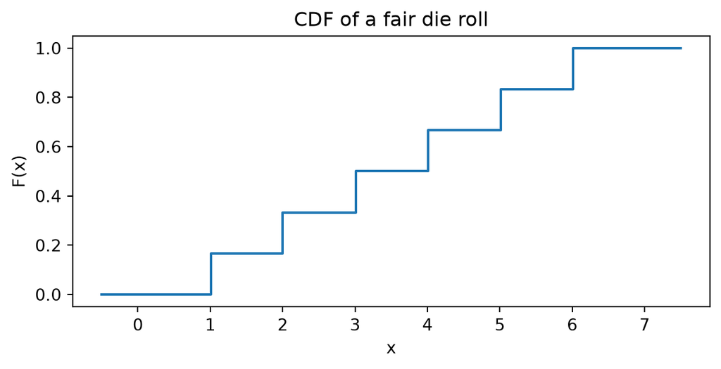

```python
die = stats.randint(1, 7)         # create the r.v.
x = np.linspace(-0.5, 7.5, 500)   # 500 points between -0.5 and 7.5

fig, ax = plt.subplots(figsize=(7, 3))
ax.step(x, die.cdf(x), where='post')    # create the step function
ax.set(xlabel='x', ylabel='F(x)', title='CDF of a fair die roll')
plt.show()
```

- $F(1.5) = \frac{1}{6}$
- $F(6) = 1$ and $F(x) = 1$ for all $x > 6$

## A question

Suppose $X$ is a person’s height, measured with unlimited precision.

**What is $\Pr[X = 70]$?**

- Commit to an answer
- What would your answer imply about the sum of probabilities over all possible heights?

## Continuous random variables

**Definition 1.2.14 — Continuous Random Variable**

A random variable $X$ is continuous if there exists a non-negative function $f: \mathbb{R} \rightarrow \mathbb{R}$ such that the CDF of $X$ is
$$F(x) = \Pr[X \leq x] = \int_{-\infty}^{x} f(u)\, du, \;\forall x \in \mathbb{R}.$$

**Definition 1.2.15 — Probability Density Function (PDF)**

For a continuous random variable $X$ with CDF $F$, the PDF of $X$ is
$$f(x) = \left.\frac{dF(u)}{du}\right|_{u=x}, \; \forall x \in \mathbb{R}.$$

## The answer: zero

From Theorem 1.2.17 (*Event Probabilities for Continuous Random Variables*):

- $\forall x \in \mathbb{R},\; \Pr[X = x] = 0$
  - Follows from $\Pr[a \leq X \leq b] = F(b) - F(a)$
  - Strict vs. weak inequalities make no difference for a continuous r.v.

## Properties of PDFs

**Theorem 1.2.16 — Properties of PDFs**

For a continuous random variable $X$ with PDF $f$,

- $\forall x \in \mathbb{R},\; f(x) \geq 0$.
- $\int_{-\infty}^{\infty} f(x)\, dx = 1$.
- Same idea as PMF properties, with integrals replacing sums
- The PDF is *density*, not probability: $f(x)$ can exceed 1
  - only areas are probabilities

## The standard uniform

**Example 1.2.18 — Standard Uniform Distribution**

If $X \sim U(0, 1)$, all values in $[0, 1]$ are equally likely: $f(x) = 1$ for $0 \leq x \leq 1$ (0 otherwise), so $F(x) = x$ on $[0, 1]$.

## The standard normal

**Example 1.2.19 — Standard Normal Distribution**

The standard normal distribution, denoted by $N(0, 1)$, has PDF $\phi$ and CDF $\Phi$:
$$\phi(x) = \frac{1}{\sqrt{2\pi}} e^{-\frac{x^2}{2}},
\quad
\Phi(x) = \int_{-\infty}^{x} \phi(u)\, du.$$

## Support

**Definition 1.2.20 — Support**

For a random variable $X$ with PMF/PDF $f$, the support of $X$ is
$$\operatorname{Supp}[X] = \{x \in \mathbb{R}: f(x) > 0\}.$$

- The values that can actually occur
  - Die roll: $\{1, \ldots, 6\}$
  - standard uniform: $[0, 1]$
- What is the support of a standard normal?

## Joint distributions

**Definition 1.3.3 — Joint PMF**

For discrete random variables $X$ and $Y$, the joint PMF of $X$ and $Y$ is
$$f(x, y) = \Pr[X = x, Y = y], \; \forall x, y \in \mathbb{R}.$$

**Example 1.3.5 — Flipping a Coin and Rolling a Die**

$X = 0$ for heads (roll a 4-sided die), $X = 1$ for tails (roll a 6-sided die); $Y$ = the roll. Then
$$f(x, y) = \begin{cases} \frac{1}{8} & : x = 0, y \in \{1,2,3,4\} \\ \frac{1}{12} & : x = 1, y \in \{1,\ldots,6\} \\ 0 & : \text{otherwise.} \end{cases}$$

## Marginal distributions

**Theorem 1.3.6 — Marginal PMF**

For discrete random variables $X$ and $Y$ with joint PMF $f$, the marginal PMF of $Y$ is
$$f_Y(y) = \Pr[Y = y] = \sum_{x \in \operatorname{Supp}[X]} f(x, y), \; \forall y \in \mathbb{R}.$$

- The distribution of $Y$ alone, ignoring $X$ — sum the joint over the other variable
- Follows from the Law of Total Probability

## Joint/marginal distributions

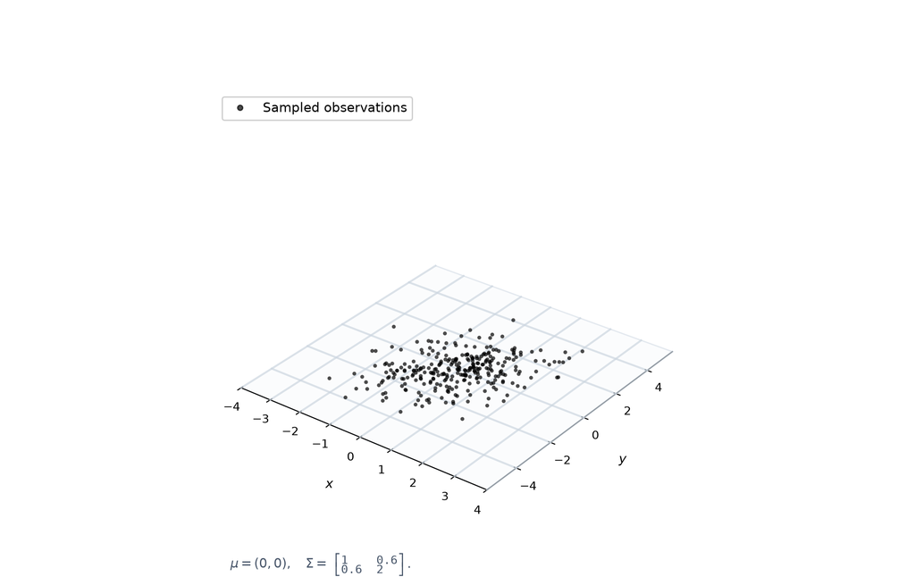

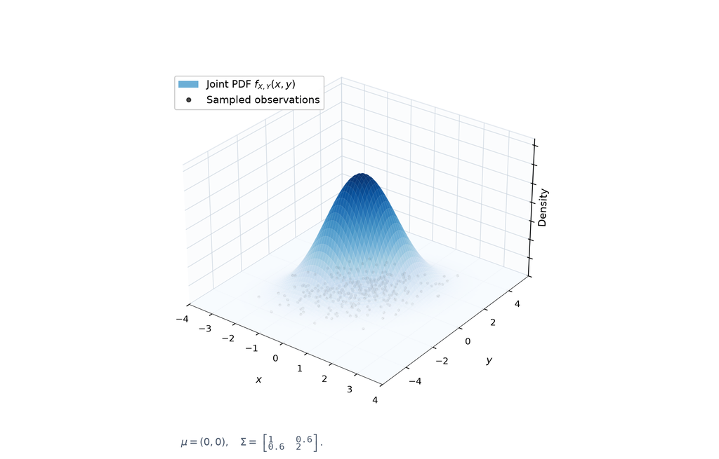

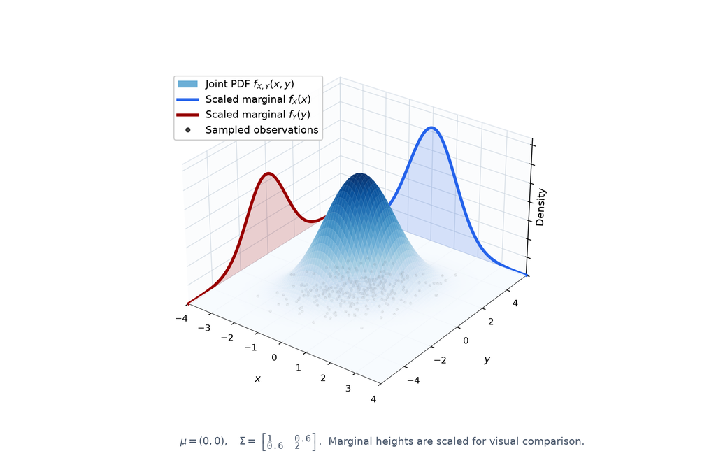

## Conditional distributions

**Definition 1.3.7 — Conditional PMF**

For discrete random variables $X$ and $Y$ with joint PMF $f$, the conditional PMF of $Y$ given $X = x$ is
$$f_{Y \mid X}(y \mid x) = \Pr[Y = y \mid X = x] = \frac{f(x, y)}{f_X(x)},$$
$\forall y \in \mathbb{R}$ and $\forall x \in \operatorname{Supp}[X]$.

- The PMF of $Y$ after “throwing out” all draws where $X \neq x$
- Same structure as conditional probability of events

## Simulations

```python
n = 100_000
X = (rng.random(n) < 0.5).astype(int)             # 1 = tails
Y = np.where(X == 0, rng.integers(1, 5, size=n),
                     rng.integers(1, 7, size=n))

print('joint    f(0,3)      ≈', ((X == 0) & (Y == 3)).mean())   # 1/8
print('marginal f_Y(3)      ≈', (Y == 3).mean())                # 5/24
print('cond.    f_X|Y(0|3)  ≈', (X[Y == 3] == 0).mean())        # 3/5
```

```
joint    f(0,3)      ≈ 0.12607
marginal f_Y(3)      ≈ 0.20858
cond.    f_X|Y(0|3)  ≈ 0.604420366286317
```

- Same generative process as the earlier Bayes example — now in random variable notation

## Continuous versions

For jointly continuous r.v.s $X$ and $Y$ with joint PDF $f$:

**Theorem 1.3.13 — Marginal PDF**

The marginal PDF of $Y$ is
$$f_Y(y) = \int_{-\infty}^{\infty} f(x, y)\, dx, \; \forall y \in \mathbb{R}.$$

**Definition 1.3.14 — Conditional PDF**

The conditional PDF of $Y$ given $X = x$ is
$$f_{Y \mid X}(y \mid x) = \frac{f(x, y)}{f_X(x)}, \; \forall y \in \mathbb{R} \text{ and } \forall x \in \operatorname{Supp}[X].$$

## Independence of random variables

**Definition 1.3.16 — Independence of Random Variables**

Let $X$ and $Y$ be either two discrete random variables with joint PMF $f$ or two jointly continuous random variables with joint PDF $f$. Then $X$ and $Y$ are independent if, $\forall x, y \in \mathbb{R}$,
$$f(x, y) = f_X(x)\, f_Y(y).$$

- Written $X \perp\!\!\!\perp Y$
- Coin-and-die: *not* independent — $f(0, 3) = \frac{1}{8} \neq \frac{1}{2} \cdot \frac{5}{24}$

## What independence buys us

**Theorem 1.3.17 — Implications of Independence (Part I)**

The following statements are equivalent:

- $X \perp\!\!\!\perp Y$
- $\forall x, y \in \mathbb{R},\; f(x, y) = f_X(x)\, f_Y(y)$
- $\forall x \in \mathbb{R}$ and $\forall y \in \operatorname{Supp}[Y]$, $f_{X \mid Y}(x \mid y) = f_X(x)$
- $\forall D, E \subseteq \mathbb{R}$, the events $\{X \in D\}$ and $\{Y \in E\}$ are independent
- For all functions $g$ of $X$ and $h$ of $Y$, $g(X) \perp\!\!\!\perp h(Y)$

## Random vectors

**Definition 1.4.1 — Random Vector**

A random vector (of length $K$) is a function $\mathbf{X}: \Omega \rightarrow \mathbb{R}^K$ such that, $\forall \omega \in \Omega$,
$$\mathbf{X}(\omega) = \left(X_{[1]}(\omega), X_{[2]}(\omega), \ldots, X_{[K]}(\omega)\right),$$
where $\forall k \in \{1, 2, \ldots, K\}$, $X_{[k]}$ is a random variable.

- Everything generalizes: joint/marginal/conditional PMFs, PDFs, CDFs
- Notation: bracketed subscripts $X_{[k]}$ for components; plain subscripts $X_i$ reserved for repeated draws (Chapter 3)

# Discussion: *Bernoulli’s Fallacy*

## Discussion — Introduction

1. Clayton contrasts “the sample ratio is close to a given urn ratio with high probability” with “the urn ratio is close to a given sample ratio with high probability.” Explain why these are different claims. For each one, say which direction the arrow runs (hypothesis → data or data → hypothesis). Then write a similar pair of statements about a setting outside the chapter, such as a weather forecast, a job interview, or a spam filter.
2. A test for a rare disease is described as “highly accurate,” yet the chapter says most positive results may be false positives. Why can both be true? What extra information do you need to find the probability that a patient who tests positive actually has the disease?
3. The prosecution in the Sally Clark case said two SIDS deaths in one family were astronomically improbable. What question did that number answer, and what question should the jury have asked instead? What other explanations would a correct analysis have had to weigh against SIDS, and how would their own probabilities matter?
4. The author says requiring a prior probability is exactly what would force “extraordinary claims” like Daryl Bem’s ESP result to meet a higher bar. Critics reply that priors make science subjective. Lay out the strongest version of each side. Does judging every hypothesis by the same sampling-probability yardstick make statistics more objective, or does it only hide a judgment call?

## Discussion — Chapter 1

1. **Testing the four definitions.** The chapter judges the classical, frequentist, subjective, and axiomatic interpretations against examples like a coin flip, tomorrow’s rain, an all-spades bridge hand, a coming election, and the cause of the dinosaur extinction. Pick two of these examples. For each one, explain which interpretations can and cannot give a meaningful probability, and why. What does the author mean by labeling the subjective view “Flexible, applies everywhere” and “Flexible, applies nowhere”?
2. **Circularity.** The author says both the classical and frequentist definitions are circular. The classical definition requires “equally likely” outcomes. The frequentist would blame bad shuffling if bridge hands came out at the “wrong” frequency. Explain each circularity in your own words. How does Jaynes’s ordering, “known facts → one-time probability → predicted frequency,” try to avoid it? Is it convincing, or is it just circular in a different way?
3. **Working the inference table.** Use the four-step table (priors, sampling probabilities, pathway probabilities, posteriors) on a problem not in the chapter. For example: a disease affects 1% of people, a test catches 90% of cases, and it gives false positives 5% of the time. What is the probability that someone who tests positive has the disease? Which column did you find hardest to fill in, and why? How does this connect to the author’s claim that sampling probabilities only *seem* easier than priors?
4. **Assumptions drive the answer in Monty Hall.** The chapter gets answers ranging from “switching always wins” to “switching always loses,” depending on what we assume about the host. List the assumptions behind the standard 2/3 answer. For two alternative assumptions, explain in words (not just numbers) why the sampling probability for the host’s action changes. Why does the author say a computer simulation can’t settle the question by itself?
5. **Subjective, objective, or both?** Jaynes claims his probabilities are subjective, because they depend on the reasoner’s background information, and objective, because any consistent reasoner with the same information must reach the same number. How do Cox’s theorem and the symmetry (indifference) argument support each half of that claim? Where would a critic like Venn or Fisher push back? Consider Bertrand’s square-and-area paradox and the question of how two people are supposed to agree on the same background information.